# Introduction to `ClusteringMetrics`

Siyuan Luo and Pierre-Luc Germain

Institute for Molecular Life Sciences, University of Zurich, Zurich, Switzerland  
Department of Health Sciences and Technology, ETH Zurich, Zurich, Switzerland

roseluosy@gmail.com

2024-10-08

#### Package

ClusteringMetrics 0.0.0.9002

# Installation & loading

```r
if (!requireNamespace("devtools", quietly = TRUE))
    install.packages("devtools")
devtools::install_github("RoseYuan/ClusteringMetrics")
```

```r
library(ClusteringMetrics)
library(ggplot2)
library(dplyr)
library(tidyr)
library(ggnetwork)
library(igraph)
library(cowplot)
```

# 1 Introduction

## 1.1 What is this package for?

This package provides multiple approaches for comparing two partitions of the same dataset, and evaluating the alignment between a dataset’s embedding/graph representations and its partition.

A partition is a way of organizing the data points of a dataset into distinct, non-overlapping, and non-empty subsets. For example, a clustering is a partition.

Besides, this package further offers methods for comparing two fuzzy partitions as well as for comparing a hard partition with a fuzzy partition. This allows the evaluation of fuzzy partition results by assessing its agreement to a fuzzy or a hard ground-truth partition.

Despite hard partitions where each data point belongs to one and only one subset, clustering can also generate fuzzy partitions. A fuzzy partition allows data points to belong to multiple subsets with varying degrees of membership.

The above mentioned metrics are all external evaluation metrics. Spatial clustering can be evaluated using external evaluation metrics of hard or fuzzy partitions, or by using internal evaluation metrics. This package also provides functions for all these types of analysis.

## 1.2 Main functions

The package *ClusteringMetrics* includes many metrics to perform different kinds of evaluations, and these metrics can be retrieved via 6 main wrapper functions. If no specified, “partition” means “hard” partition. They are:

- `getEmbeddingMetrics()`: Metrics to compare an embedding of data points to a partition of these data points.
- `getGraphMetrics()`: Metrics to compare a graph to a partition, where nodes in the graph are data points in the partition.
- `getPartitionMetrics()`: Metrics to compare two partitions of the same dataset.
- `getfuzzyPartitionMetrics()`: Metrics to compare two fuzzy partitions, or to compare between a fuzzy and a hard partition of the same dataset.
- `getSpatialExternalMetrics()`: External metrics for evaluating spatial clustering results in a spatial-aware fashion. For non-spatial-aware evaluation, one can directly use `getPartitionMetrics()`.
- `getSpatialInternalMetrics()`: Internal metrics for evaluating spatial clustering results in a spatial-aware fashion.

There are 3 different levels where one can perform the above-mentioned evaluation: element-level, class-level, and global-level. Element-level evaluation reports metric values for each data point; Class-level evaluation reports metrics for each classes or clusters; and global-level evaluation returns a single metric value for the whole dataset.

In this vignette, classes refer to groups in the **ground-truth** partition.

In this vignette, clusters refer to groups in the **predicted** partition.

The following table illustrates available metrics at different evaluation levels, and the main functions used to retrieve them.

```r
DT::datatable(metric_info)
```

|  | Name | Levels | MainFunction | Description |
| --- | --- | --- | --- | --- |
| 1 | AMI | global | getPartitionMetrics | Adjusted Mutual Information |
| 2 | AMSP | class, global | getGraphMetrics | Adjusted Mean Shortest Path |
| 3 | ARI | global | getPartitionMetrics | Adjusted Rand Index |
| 4 | AWC | class, global | getPartitionMetrics | Adjusted Wallace Completeness |
| 5 | AWH | class, global | getPartitionMetrics | Adjusted Wallace Homogeneity |
| 6 | CHAOS | class, global | getSpatialInternalMetrics | Spatial Chaos Score |
| 7 | EC | global | getPartitionMetrics | (Entropy-based) Completeness |
| 8 | EH | global | getPartitionMetrics | (Entropy-based) Homogeneity |
| 9 | ELSA | elelemt, class, global | getSpatialInternalMetrics | Entropy-based Local Indicator of Spatial Association (ELSA score) |
| 10 | FM | class, global | getPartitionMetrics | F-measure/weighted average F1 score |

[output cut: 47 more lines]

# 2 Getting started

## 2.1 Example data

The two datasets, `g1` and `g2`, both contain 80 data points with `x` and `y` coordinates and of 4 different classes.

```r
data(toyExamples)
g1 <- toyExamples[toyExamples$graph=="graph1",]
g2 <- toyExamples[toyExamples$graph=="graph2",]
head(g1)
```

```
##      graph          x         y  class
## 641 graph1 -0.6290416 -0.487293 class1
## 642 graph1 -2.5646982 -1.742079 class1
## 643 graph1 -1.6368716 -1.911560 class1
## 644 graph1 -1.3671374 -2.120897 class1
## 645 graph1 -1.5957317 -3.194329 class1
## 646 graph1 -2.1061245 -1.388003 class1
```

If we plot them out:

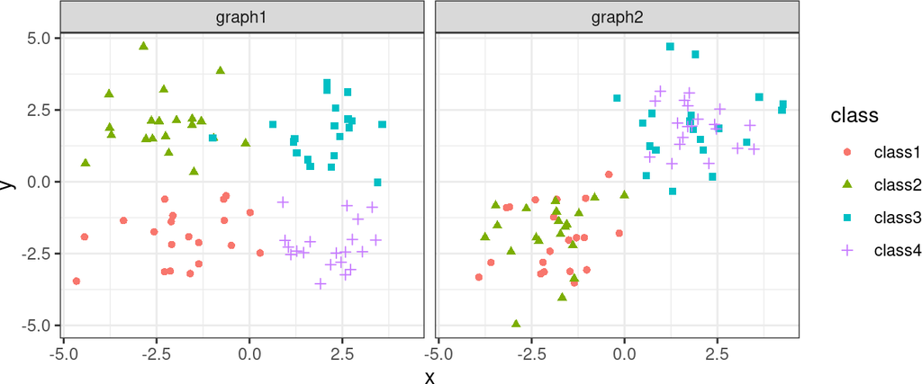

```r
ggplot(rbind(g1,g2), aes(x,y,color=class, shape=class)) +
  geom_point() +
  facet_wrap(~graph) +
  theme_bw()
```

# 3 Embedding evaluation

Let’s assume `g1` and `g2` contain two different embeddings of the same set of objects. A “good” embedding should put objects of the same class together, and objects of different class apart. With the ground-truth class of each object already known, one can evaluation such “goodness” of an embedding by calculating embedding evaluation metrics.

## 3.1 Element-level evaluation

For example, at the element level, one can calculate the Silhouette Width by specifying `level="element"` and `metrics=c("SW")`:

```r
sw <- getEmbeddingMetrics(x=g1[,c("x","y")], labels=g1$class, metrics=c("SW"), level="element")
head(sw)
```

```
##      class        SW
## 641 class1 0.2986628
## 642 class1 0.5818507
## 643 class1 0.6299871
## 644 class1 0.5867285
## 645 class1 0.5191290
## 646 class1 0.5679847
```

The output will be a `data.frame` containing the metric values for the specified level.

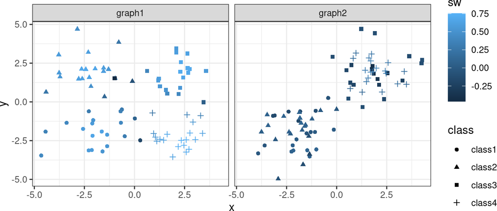

```r
g1$sw <- getEmbeddingMetrics(x=g1[,c("x","y")], labels=g1$class, metrics=c("SW"), level="element")$SW
g2$sw <- getEmbeddingMetrics(x=g2[,c("x","y")], labels=g2$class, metrics=c("SW"), level="element")$SW
ggplot(rbind(g1,g2), aes(x, y, color=sw, shape=class)) +
  geom_point() +
  facet_wrap(~graph) +
  theme_bw()
```

## 3.2 Class-level evaluation

One can also evaluate at each class level, by specifying `level="class"`. Check `?getEmbeddingMetrics` to see what are the allowed metrics at the class level. For example:

```r
cl <- getEmbeddingMetrics(x=g1[,c("x","y")], labels=g1$class, metrics=c("dbcv", "meanSW"), level="class")
head(cl)
```

```
##    class    meanSW        dbcv
## 1 class1 0.4240817 -0.37367780
## 2 class2 0.4897828 -0.34617982
## 3 class3 0.5021555  0.07752233
## 4 class4 0.5957709  0.26757842
```

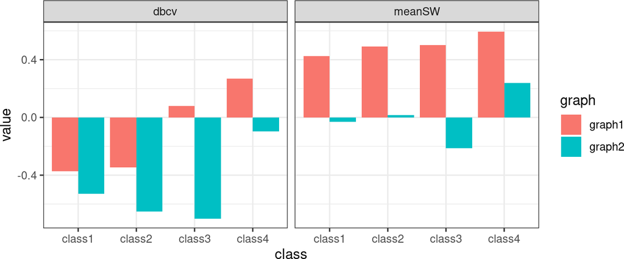

```r
res1 <- getEmbeddingMetrics(x=g1[,c("x","y")], labels=g1$class, metrics=c("dbcv", "meanSW"), level="class")
res2 <- getEmbeddingMetrics(x=g2[,c("x","y")], labels=g2$class, metrics=c("dbcv", "meanSW"), level="class")

bind_rows(list(graph1=res1, graph2=res2), .id="graph") %>% pivot_longer(cols=c("meanSW","dbcv"), names_to="metric",values_to="value") %>%
ggplot(aes(class, value, fill=graph, group=graph)) +
  geom_bar(position = "dodge", stat = "identity") +
  facet_wrap(~metric) +
  theme_bw()
```

## 3.3 Global-level evaluation

Similarly, one can evaluate at the global level by specifying `level="global"`. For example:

```r
getEmbeddingMetrics(x=g1[,c("x","y")], labels=g1$class, metrics=c("meanSW", "meanClassSW", "pnSW", "minClassSW", "cdbw", "cohesion", "compactness", "sep", "dbcv"), level="global")
```

```
##      meanSW meanClassSW   pnSW minClassSW      cdbw  cohesion compactness
## 1 0.5029477   0.5029477 0.0375  0.4240817 0.0553208 0.2732925   0.2800803
##         sep        dbcv
## 1 0.7227335 -0.09368922
```

# 4 Graph evaluation

Instead of directly using the distances or densities in the embedding space for evaluation, one may want to evaluate from a connectivity stand point by looking at the graph structure constructed from the above datasets. `getGraphMetrics()` can perform k nearest neighbor (KNN) graph or shared nearest neighbor graph (SNN) construction from an embedding and then apply graph-based evaluation metrics.

```r
# Some functions for plotting
plotGraphs <- function(d, k=7){
  gn <- dplyr::bind_rows(lapply(split(d[,-1],d$graph), FUN=function(d1){
    g <- knn2graph(df2knn(d1, k=k))
    ggnetwork(g, layout=as.matrix(d1[,1:2]), scale=FALSE)
  }), .id="graph")
  ggplot(gn, aes(x = x, y = y, xend = xend, yend = yend)) + theme_blank() + theme(legend.position = "right") +
  geom_edges(alpha=0.5, colour="grey") + geom_nodes(aes(colour=class, shape=class), size=2) + facet_wrap(~graph, nrow=1)
}
df2knn <- function(d1, k=7, ...){
  knn <- BiocNeighbors::findKNN(d1[,1:2], k=k, ...)
  knn$class <- factor(d1$class)
  knn
}
knn2graph <- function(knn, directed=FALSE){
  g <- bluster::neighborsToKNNGraph(knn$index, directed=directed)
  g <- set_vertex_attr(g, "class", value=factor(knn$class))
  g <- set_vertex_attr(g, "id", value=seq_along(V(g)))
  g
}
```

For our examples `g1` and `g2`, the constucted graphs will look like:

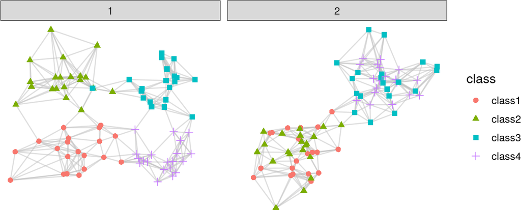

```r
plotGraphs(bind_rows(list(g1,g2), .id="graph"))
```

Use `?getGraphMetrics()` to check optional arguments for KNN/SNN graph construction.

Similarly, `level` can be `"element"`, `"class"` or `"global"`.

```r
getGraphMetrics(x=g1[,c("x","y")], labels=g1$class, metrics=c("PWC","ISI"), level="class", directed=FALSE, k=7, shared=FALSE)
```

```
##         class  PWC      ISI
## class1 class1 0.05 1.186272
## class2 class2 0.10 1.224188
## class3 class3 0.05 1.149098
## class4 class4 0.05 1.251146
```

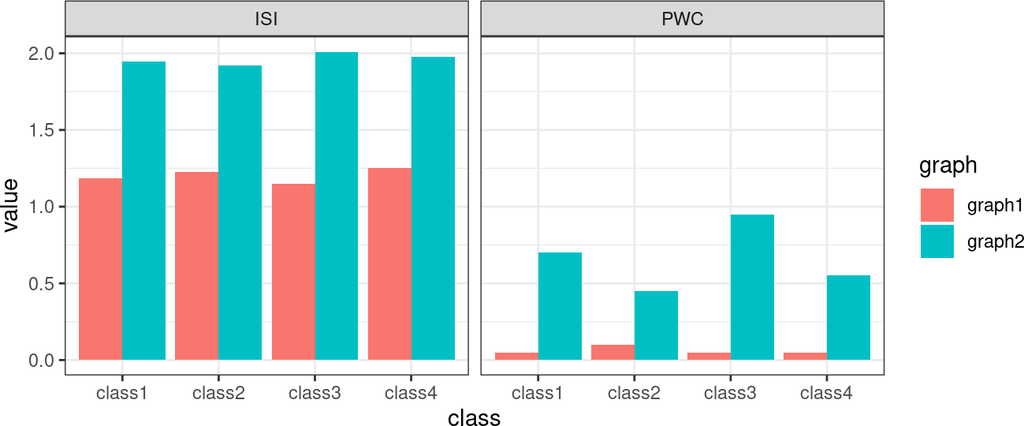

```r
res1 <- getGraphMetrics(x=g1[,c("x","y")], labels=g1$class, metrics=c("PWC","ISI"), level="class", directed=FALSE, k=7, shared=FALSE)
res2 <- getGraphMetrics(x=g2[,c("x","y")], labels=g2$class, metrics=c("PWC","ISI"), level="class", directed=FALSE, k=7, shared=FALSE)

bind_rows(list(graph1=res1, graph2=res2), .id="graph") %>% pivot_longer(cols=c("PWC","ISI"), names_to="metric",values_to="value") %>%
ggplot(aes(class, value, fill=graph, group=graph)) +
  geom_bar(position = "dodge", stat = "identity") +
  facet_wrap(~metric) +
  theme_bw()
```

Alternatively, `getGraphMetrics()` can take an *igraph* object as `x`, which enables the application of the evaluation metrics to a general graph, or a list of nearest neighbors as `x`, to accelerate the computation for large datasets.

# 5 Partition evaluation

We construct SNN graph from g1 and g2 embeddings, and then apply Louvain algorithm to get partitions out of them.

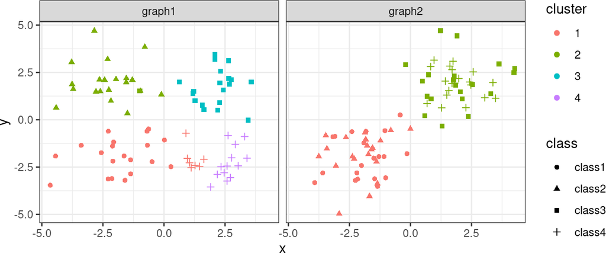

```r
k <- 7
r <- 0.5
snn1 <- ClusteringMetrics:::.emb2snn(as.matrix(g1[,c("x","y")]), k=k)
snn2 <- ClusteringMetrics:::.emb2snn(as.matrix(g2[,c("x","y")]), k=k)
g1$cluster <- factor(igraph::cluster_louvain(snn1, resolution = r)$membership)
g2$cluster <- factor(igraph::cluster_louvain(snn2, resolution = r)$membership)

ggplot(rbind(g1,g2), aes(x,y,color=cluster, shape=class)) +
  geom_point() +
  facet_wrap(~graph) +
  theme_bw()
```

We then compare the predictions with the known labels using the partition metrics:

```r
# for g1
getPartitionMetrics(true=g1$class, pred=g1$cluster, level="global",
                    metrics = c("RI", "WC", "WH", "ARI", "AWC", "AWH",
                                "FM", "AMI"))
```

```
##         RI        WC        WH       ARI       AWC       AWH        FM
## 1 0.914557 0.8552632 0.8024691 0.7712601 0.8053751 0.7399177 0.8972278
##         AMI
## 1 0.8164395
```

```r
# for g2
getPartitionMetrics(true=g2$class, pred=g2$cluster, level="global",
                    metrics = c("RI", "WC", "WH", "ARI", "AWC", "AWH",
                                "FM", "AMI"))
```

```
##          RI WC        WH       ARI AWC       AWH        FM       AMI
## 1 0.7468354  1 0.4871795 0.4903226   1 0.3247863 0.6666667 0.4929144
```

Note that for class-level metrics, some are reported per class, while some (specifically, “WH”, “AWH) are reported per cluster.

```r
getPartitionMetrics(true=g1$class, pred=g2$cluster, level="class")
```

```
##   WC AWC        FM  class        WH       AWH cluster
## 1  1   1 0.6666667 class1        NA        NA    <NA>
## 2  1   1 0.6666667 class2        NA        NA    <NA>
## 3  1   1 0.6666667 class3        NA        NA    <NA>
## 4  1   1 0.6666667 class4        NA        NA    <NA>
## 5 NA  NA        NA   <NA> 0.4871795 0.3247863       1
## 6 NA  NA        NA   <NA> 0.4871795 0.3247863       2
```

# 6 Fuzzy partition evaluation

For comparing two fuzzy partitions or comparing a fuzzy partition to a hard patition, one can use `getFuzzyPartitionMetrics()`.

The fuzzy reprensentation of a partion should look like the following, where each row is a data point, and the value is the class memberships to each class. Each row sums up to 1.

```r
fuzzyTrue <- matrix(c(
  0.95, 0.025, 0.025,
  0.98, 0.01, 0.01,
  0.96, 0.02, 0.02,
  0.95, 0.04, 0.01,
  0.95, 0.01, 0.04,
  0.99, 0.005, 0.005,
  0.025, 0.95, 0.025,
  0.97, 0.02, 0.01,
  0.025, 0.025, 0.95),
  ncol = 3, byrow=TRUE)
fuzzyTrue
```

```
##        [,1]  [,2]  [,3]
##  [1,] 0.950 0.025 0.025
##  [2,] 0.980 0.010 0.010
##  [3,] 0.960 0.020 0.020
##  [4,] 0.950 0.040 0.010
##  [5,] 0.950 0.010 0.040
##  [6,] 0.990 0.005 0.005
##  [7,] 0.025 0.950 0.025
##  [8,] 0.970 0.020 0.010
##  [9,] 0.025 0.025 0.950
```

```r
# a hard truth:
hardTrue <- apply(fuzzyTrue,1,FUN=which.max)
# some predicted labels:
hardPred <- c(1,1,1,1,1,1,2,2,2)
getFuzzyPartitionMetrics(hardPred=hardPred, hardTrue=hardTrue, fuzzyTrue=fuzzyTrue, nperms=3, level="class", fuzzy_true = TRUE, fuzzy_pred = FALSE)
```

```
##     fuzzyWC  fuzzyAWC class    fuzzyWH  fuzzyAWH cluster
## 1 0.7195238 0.4674503     1         NA        NA      NA
## 2 1.0000000       NaN     2         NA        NA      NA
## 3 1.0000000       NaN     3         NA        NA      NA
## 4        NA        NA    NA 1.00000000  1.000000       1
## 5        NA        NA    NA 0.06166667 -3.433071       2
```

By specifying `fuzzy_true` and `fuzzy_pred`, one can control whether the fuzzy or hard version of the two partitions is used in comparison. This should be consistent with the input `hardPred`, `hardTrue`, `fuzzyPred`, `fuzzyTrue`, e.g. when `fuzzy_true=TRUE`, `fuzzyTrue` should not be `NULL`.

# 7 Spatial clustering evaluation

## 7.1 Example data

We use another toy example dataset in the package, `sp_toys`, to illustrate spatial clustering evaluation.

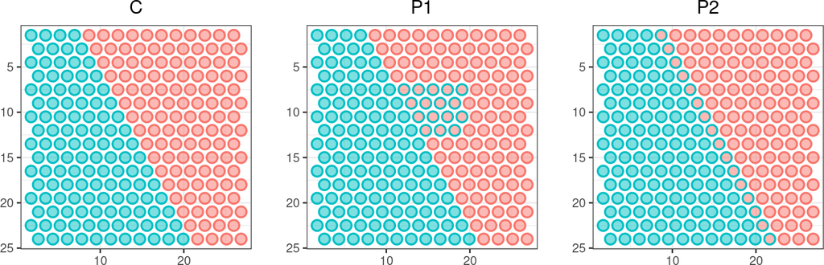

```r
s <- 3
st <- 1
p1 <- ggplot(sp_toys, aes(x, y,
               color=label)) +
  geom_point(size=s, alpha=0.5) + scale_y_reverse() + theme_bw() +
  geom_point(shape = 1, size = s, stroke = st, aes(color=p1)) +
  labs(x="",y="", title="P1")

p0 <- ggplot(sp_toys, aes(x, y,
               color=label)) +
  geom_point(size=s, alpha=0.5) + scale_y_reverse() + theme_bw() +
  geom_point(shape = 1, size = s, stroke = st, aes(color=label)) +
  labs(x="",y="", title="C")
p2 <- ggplot(sp_toys, aes(x, y,
               color=label)) +
  geom_point(size=s, alpha=0.5) + scale_y_reverse() + theme_bw() +
  geom_point(shape = 1, size = s, stroke = st, aes(color=p2)) +
  labs(x="",y="", title="P2")

plot_grid(p0 + theme(legend.position = "none",
                     plot.title = element_text(hjust = 0.5)),
          p1 + theme(legend.position = "none",
                     plot.title = element_text(hjust = 0.5)),
          p2 + theme(legend.position = "none",
                     plot.title = element_text(hjust = 0.5)), ncol = 3)
```

Here in C, the spots are colored by the ground-truth class. In P1 and P2, the color inside each spot is according to the ground-truth class, while the color of the border is according to clustering predictions. P1 and P2 misclassified the same amount of red spots into the blue cluster.

## 7.2 External metrics

Let’s quantify this by calculating external spatial metrics:

```r
getSpatialExternalMetrics(true=sp_toys$label, pred=sp_toys$p1,
                      location=sp_toys[,c("x","y")], level="global",
                      metrics=c("SpatialARI","SpatialAccuracy"),
                      fuzzy_true = TRUE, fuzzy_pred = FALSE)
```

```
##   SpatialARI SpatialAccuracy
## 1  0.7544195       0.9388889
```

```r
getSpatialExternalMetrics(true=sp_toys$label, pred=sp_toys$p1,
                      location=sp_toys[,c("x","y")], level="class")
```

```
##   SpatialWH SpatialAWH SpatialWC SpatialAWC class cluster
## 1        NA         NA  0.779245  0.5340122     1      NA
## 2        NA         NA  1.000000  1.0000000     2      NA
## 3  1.000000  1.0000000        NA         NA    NA       1
## 4  0.804378  0.5907709        NA         NA    NA       2
```

```r
res1.1 <- getSpatialExternalMetrics(true=sp_toys$label, pred=sp_toys$p1,
                      location=sp_toys[,c("x","y")], level="global",
                      metrics=c("SpatialARI","SpatialAccuracy"),
                      fuzzy_true = TRUE, fuzzy_pred = FALSE)
res2.1 <- getSpatialExternalMetrics(true=sp_toys$label, pred=sp_toys$p2,
                      location=sp_toys[,c("x","y")], level="global",
                      metrics=c("SpatialARI","SpatialAccuracy"),
                      fuzzy_true = TRUE, fuzzy_pred = FALSE)
res1.2 <- getPartitionMetrics(true=sp_toys$label, pred=sp_toys$p1,
                      level="global", metrics=c("ARI"))
res2.2 <- getPartitionMetrics(true=sp_toys$label, pred=sp_toys$p2,
                      level="global", metrics=c("ARI"))
```

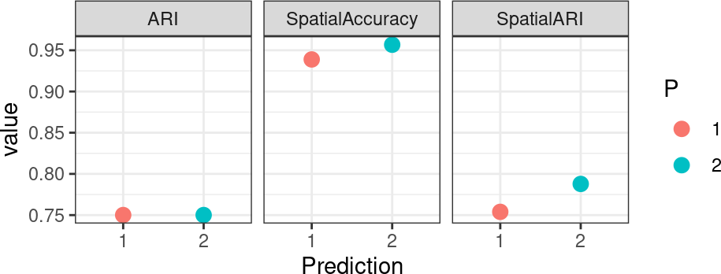

```r
cbind(bind_rows(list(res1.1, res2.1), .id="P"),
      bind_rows(list(res1.2, res2.2), .id="P")) %>%
  pivot_longer(cols=c("SpatialARI", "SpatialAccuracy", "ARI"),
               names_to="metric", values_to="value") %>%
  ggplot(aes(x=P, y=value, group=metric)) +
  geom_point(size=3, aes(color=P)) +
  facet_wrap(~metric) +
  theme_bw() + labs(x="Prediction")
```

When the evaluation is non-spatial-aware, P1 and P2 get the same ARI score. However, with spatial-aware metrics like SpatialARI and SpatialAccuracy, P2 gets a higher scores than P1.

## 7.3 Internal metrics

Last but not least, there are internal metrics for spatial clustering evaluation:

```r
sp_toys$c_elsa <- getSpatialInternalMetrics(label=sp_toys$label,
                      location=sp_toys[,c("x","y")], level="element",
                      metrics=c("ELSA"))$ELSA
sp_toys$p1_elsa <- getSpatialInternalMetrics(label=sp_toys$p1,
                      location=sp_toys[,c("x","y")], level="element",
                      metrics=c("ELSA"))$ELSA
sp_toys$p2_elsa <- getSpatialInternalMetrics(label=sp_toys$p2,
                      location=sp_toys[,c("x","y")], level="element",
                      metrics=c("ELSA"))$ELSA
```

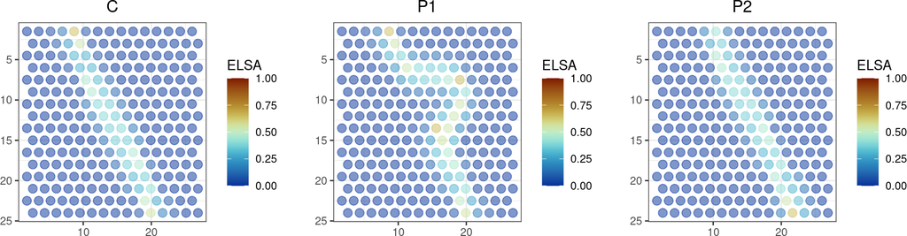

```r
s <- 3
st <- 1
p1 <- ggplot(sp_toys, aes(x, y,
               color=p1_elsa)) +
  geom_point(size=s, alpha=0.5) + scale_y_reverse() + theme_bw() +
  labs(x="",y="", title="P1", color="ELSA") +
  scico::scale_color_scico(palette = "roma", limits = c(0, 1), direction=-1)

p0 <- ggplot(sp_toys, aes(x, y,
               color=c_elsa)) +
  geom_point(size=s, alpha=0.5) + scale_y_reverse() + theme_bw() +
  labs(x="",y="", title="C", color="ELSA") +
  scico::scale_color_scico(palette = "roma", limits = c(0, 1), direction=-1)
p2 <- ggplot(sp_toys, aes(x, y,
               color=p2_elsa)) +
  geom_point(size=s, alpha=0.5) + scale_y_reverse() + theme_bw() +
  labs(x="",y="", title="P2", color="ELSA") +
  scico::scale_color_scico(palette = "roma", limits = c(0, 1), direction=-1)

plot_grid(p0 + theme(plot.title = element_text(hjust = 0.5)),
          p1 + theme(plot.title = element_text(hjust = 0.5)),
          p2 + theme(plot.title = element_text(hjust = 0.5)), nrow=1, rel_width=c(1,1,1))
```